# Impact of Severe Weather on Population Health and Economy in the US

Ayo Johnson

5/9/2017

## Introduction

This project explores data from the U.S. National Oceanic and Atmospheric Administration’s (NOAA) storm database. Its aim is to determine:

1. Across the United States, which types of events are most harmful with respect to population health?
2. Across the United States, which types of events have the greatest economic consequences?

Policy makers may use its findings as a guide for resource allocation before during and after severe weather events.

## Data Processing

Libraries used for this project

```r
library(data.table)
library(lubridate)
```

```r
library(date)
library(dtplyr)
library(ggplot2)
```

Loading Data and Preprocessing

```r
knitr::opts_chunk$set(cache = TRUE)
StormData <- fread ("/Users/ayojohnson/Coursera/ReproducibleResearch/repdata-data-StormData.csv")
```

```
##
Read 17.6% of 967216 rows
Read 38.3% of 967216 rows
Read 55.8% of 967216 rows
Read 79.6% of 967216 rows
Read 902297 rows and 37 (of 37) columns from 0.523 GB file in 00:00:07
```

```r
dim(StormData)
```

```
## [1] 902297     37
```

```r
head(StormData, n = 2)
```

```
##    STATE__          BGN_DATE BGN_TIME TIME_ZONE COUNTY COUNTYNAME STATE
## 1:       1 4/18/1950 0:00:00     0130       CST     97     MOBILE    AL
## 2:       1 4/18/1950 0:00:00     0145       CST      3    BALDWIN    AL
##     EVTYPE BGN_RANGE BGN_AZI BGN_LOCATI END_DATE END_TIME COUNTY_END
## 1: TORNADO         0                                               0
## 2: TORNADO         0                                               0
##    COUNTYENDN END_RANGE END_AZI END_LOCATI LENGTH WIDTH F MAG FATALITIES
## 1:         NA         0                        14   100 3   0          0
## 2:         NA         0                         2   150 2   0          0
##    INJURIES PROPDMG PROPDMGEXP CROPDMG CROPDMGEXP WFO STATEOFFIC ZONENAMES
## 1:       15    25.0          K       0
## 2:        0     2.5          K       0
##    LATITUDE LONGITUDE LATITUDE_E LONGITUDE_ REMARKS REFNUM
## 1:     3040      8812       3051       8806              1
## 2:     3042      8755          0          0              2
```

```r
tail(StormData, n = 2)
```

```
##    STATE__           BGN_DATE    BGN_TIME TIME_ZONE COUNTY COUNTYNAME
## 1:       2  11/9/2011 0:00:00 10:21:00 AM       AKS    202     AKZ202
## 2:       1 11/28/2011 0:00:00 08:00:00 PM       CST      6     ALZ006
##    STATE     EVTYPE BGN_RANGE BGN_AZI BGN_LOCATI           END_DATE
## 1:    AK   BLIZZARD         0                     11/9/2011 0:00:00
## 2:    AL HEAVY SNOW         0                    11/29/2011 0:00:00
##       END_TIME COUNTY_END COUNTYENDN END_RANGE END_AZI END_LOCATI LENGTH
## 1: 05:00:00 PM          0         NA         0                         0
## 2: 04:00:00 AM          0         NA         0                         0
##    WIDTH F MAG FATALITIES INJURIES PROPDMG PROPDMGEXP CROPDMG CROPDMGEXP
## 1:     0     0          0        0       0          K       0          K
## 2:     0     0          0        0       0          K       0          K
##    WFO       STATEOFFIC                                     ZONENAMES
## 1: AFG ALASKA, Northern NORTHERN ARCTIC COAST - NORTHERN ARCTIC COAST
## 2: HUN   ALABAMA, North                             MADISON - MADISON
##    LATITUDE LONGITUDE LATITUDE_E LONGITUDE_
## 1:        0         0          0          0
## 2:        0         0          0          0
##                                                                                                                                                                                                                                                                                                          …
## 1: EPISODE NARRATIVE: A 960 mb low over the southern Aleutians at 0300AKST on the 8th intensified to 945 mb near the Gulf of Anadyr by 2100AKST on the 8th. The low crossed the Chukotsk Peninsula as a 956 mb low at 0900AKST on the 9th, and moved into the southern Chukchi Sea as a 958 mb low by 210…
## 2:                           EPISODE NARRATIVE: An intense upper level low developed on the 28th at the base of a highly amplified upper trough across the Great Lakes and Mississippi Valley.  The upper low closed off over the mid South and tracked northeast across the Tennessee Valley during the …
##    REFNUM
## 1: 902296
## 2: 902297
```

Checking where the NAs are

```r
colSums(is.na(StormData))
```

```
##    STATE__   BGN_DATE   BGN_TIME  TIME_ZONE     COUNTY COUNTYNAME
##          0          0          0          0          0          0
##      STATE     EVTYPE  BGN_RANGE    BGN_AZI BGN_LOCATI   END_DATE
##          0          0          0          0          0          0
##   END_TIME COUNTY_END COUNTYENDN  END_RANGE    END_AZI END_LOCATI
##          0          0     902297          0          0          0
##     LENGTH      WIDTH          F        MAG FATALITIES   INJURIES
##          0          0          0          0          0          0
##    PROPDMG PROPDMGEXP    CROPDMG CROPDMGEXP        WFO STATEOFFIC
##          0          0          0          0          0          0
##  ZONENAMES   LATITUDE  LONGITUDE LATITUDE_E LONGITUDE_    REMARKS
##          0         47          0         40          0          0
##     REFNUM
##          0
```

Checking column names

```r
colnames(StormData)
```

```
##  [1] "STATE__"    "BGN_DATE"   "BGN_TIME"   "TIME_ZONE"  "COUNTY"
##  [6] "COUNTYNAME" "STATE"      "EVTYPE"     "BGN_RANGE"  "BGN_AZI"
## [11] "BGN_LOCATI" "END_DATE"   "END_TIME"   "COUNTY_END" "COUNTYENDN"
## [16] "END_RANGE"  "END_AZI"    "END_LOCATI" "LENGTH"     "WIDTH"
## [21] "F"          "MAG"        "FATALITIES" "INJURIES"   "PROPDMG"
## [26] "PROPDMGEXP" "CROPDMG"    "CROPDMGEXP" "WFO"        "STATEOFFIC"
## [31] "ZONENAMES"  "LATITUDE"   "LONGITUDE"  "LATITUDE_E" "LONGITUDE_"
## [36] "REMARKS"    "REFNUM"
```

Checking data structure

```r
str(StormData)
```

[output not shown]

checking again

```r
tables()
```

```
##      NAME         NROW NCOL  MB
## [1,] StormData 902,297   37 471
##      COLS
## [1,] STATE__,BGN_DATE,BGN_TIME,TIME_ZONE,COUNTY,COUNTYNAME,STATE,EVTYPE,BGN_RANGE,BGN
##      KEY
## [1,]
## Total: 471MB
```

```r
Events <- unique(StormData$EVTYPE)
length(Events)
```

```
## [1] 985
```

For the purpose of analysing the impact of different weather events on the economy and public health across the United States the following variables are most relevant:

- EVTYPE : type of weather event
- STATE : State
- FATALITIES : Number of deaths
- INJURIES : Number of injuries
- PROPDMG : Value of property damage
- CROPDMG : Value of crop damage
- PROPDMGEXP : exponent of value of property damage
- CROPDMGEXP: exponent of value of cost damage

According to the official documentation of the data, collection of storm events began in 1950 but it was only until 1996 that the full spectrum of weather events began to be collected. The documentation also notes that each entry is given a reference number (variable Refnum). It appears from our initial examination that the refnum are in numerical order. For these reasons we will retain the variables REFNUM and BGN_DATE (date of start of event). This enables random sampling of the data as well as analysis of weather events by year. Including the state allows analysis by state - assuming, for instance, that some states may have characteristics - such as architecture and geography which might affect impacts of severe storms.

With these points in mind we’ll subset the data to include only the variables identified above from the year 1996.

Now we can select the relevant data

```r
StormData <- select(StormData,REFNUM,EVTYPE,BGN_DATE,STATE,FATALITIES,INJURIES,PROPDMG,PROPDMGEXP,CROPDMG,CROPDMGEXP)
head (StormData, n = 2)
```

```
##    REFNUM  EVTYPE          BGN_DATE STATE FATALITIES INJURIES PROPDMG
## 1:      1 TORNADO 4/18/1950 0:00:00    AL          0       15    25.0
## 2:      2 TORNADO 4/18/1950 0:00:00    AL          0        0     2.5
##    PROPDMGEXP CROPDMG CROPDMGEXP
## 1:          K       0
## 2:          K       0
```

```r
##table(StormData)
tables()
```

```
##      NAME         NROW NCOL MB
## [1,] StormData 902,297   10 71
##      COLS
## [1,] REFNUM,EVTYPE,BGN_DATE,STATE,FATALITIES,INJURIES,PROPDMG,PROPDMGEXP,CROPDMG,CROP
##      KEY
## [1,]
## Total: 71MB
```

```r
str(StormData)
```

```
## Classes 'data.table' and 'data.frame':   902297 obs. of  10 variables:
##  $ REFNUM    : num  1 2 3 4 5 6 7 8 9 10 ...
##  $ EVTYPE    : chr  "TORNADO" "TORNADO" "TORNADO" "TORNADO" ...
##  $ BGN_DATE  : chr  "4/18/1950 0:00:00" "4/18/1950 0:00:00" "2/20/1951 0:00:00" "6/8/1951 0:00:00" ...
##  $ STATE     : chr  "AL" "AL" "AL" "AL" ...
##  $ FATALITIES: num  0 0 0 0 0 0 0 0 1 0 ...
##  $ INJURIES  : num  15 0 2 2 2 6 1 0 14 0 ...
##  $ PROPDMG   : num  25 2.5 25 2.5 2.5 2.5 2.5 2.5 25 25 ...
##  $ PROPDMGEXP: chr  "K" "K" "K" "K" ...
##  $ CROPDMG   : num  0 0 0 0 0 0 0 0 0 0 ...
##  $ CROPDMGEXP: chr  "" "" "" "" ...
##  - attr(*, ".internal.selfref")=<externalptr>
```

House-keeping: Convert BGN_DATE to date format

```r
#StormData$BGN_DATE <- as.Date(StormData$BGN_DATE, "%m/%d/%Y %H:%M:%S")
StormData$BGN_DATE <- mdy_hms(StormData$BGN_DATE)
class(StormData$BGN_DATE)
```

```
## [1] "POSIXct" "POSIXt"
```

```r
dim(StormData)
```

```
## [1] 902297     10
```

```r
str(StormData)
```

```
## Classes 'data.table' and 'data.frame':   902297 obs. of  10 variables:
##  $ REFNUM    : num  1 2 3 4 5 6 7 8 9 10 ...
##  $ EVTYPE    : chr  "TORNADO" "TORNADO" "TORNADO" "TORNADO" ...
##  $ BGN_DATE  : POSIXct, format: "1950-04-18" "1950-04-18" ...
##  $ STATE     : chr  "AL" "AL" "AL" "AL" ...
##  $ FATALITIES: num  0 0 0 0 0 0 0 0 1 0 ...
##  $ INJURIES  : num  15 0 2 2 2 6 1 0 14 0 ...
##  $ PROPDMG   : num  25 2.5 25 2.5 2.5 2.5 2.5 2.5 25 25 ...
##  $ PROPDMGEXP: chr  "K" "K" "K" "K" ...
##  $ CROPDMG   : num  0 0 0 0 0 0 0 0 0 0 ...
##  $ CROPDMGEXP: chr  "" "" "" "" ...
##  - attr(*, ".internal.selfref")=<externalptr>
```

Now we select only those records with a BGN_DATE post 01/01/1996

```r
StormData <- filter(StormData, year(BGN_DATE) >= "1996")
head(StormData)
```

```
##    REFNUM       EVTYPE   BGN_DATE STATE FATALITIES INJURIES PROPDMG
## 1: 248768 WINTER STORM 1996-01-06    AL          0        0     380
## 2: 248769      TORNADO 1996-01-11    AL          0        0     100
## 3: 248770    TSTM WIND 1996-01-11    AL          0        0       3
## 4: 248771    TSTM WIND 1996-01-11    AL          0        0       5
## 5: 248772    TSTM WIND 1996-01-11    AL          0        0       2
## 6: 248773         HAIL 1996-01-18    AL          0        0       0
##    PROPDMGEXP CROPDMG CROPDMGEXP
## 1:          K      38          K
## 2:          K       0
## 3:          K       0
## 4:          K       0
## 5:          K       0
## 6:                  0
```

```r
tail(StormData)
```

```
##    REFNUM         EVTYPE   BGN_DATE STATE FATALITIES INJURIES PROPDMG
## 1: 902292 WINTER WEATHER 2011-11-28    TN          0        0       0
## 2: 902293      HIGH WIND 2011-11-30    WY          0        0       0
## 3: 902294      HIGH WIND 2011-11-10    MT          0        0       0
## 4: 902295      HIGH WIND 2011-11-08    AK          0        0       0
## 5: 902296       BLIZZARD 2011-11-09    AK          0        0       0
## 6: 902297     HEAVY SNOW 2011-11-28    AL          0        0       0
##    PROPDMGEXP CROPDMG CROPDMGEXP
## 1:          K       0          K
## 2:          K       0          K
## 3:          K       0          K
## 4:          K       0          K
## 5:          K       0          K
## 6:          K       0          K
```

```r
#tables(StormData)
dim(StormData)
```

```
## [1] 653530     10
```

Let’s take an exploratory look at this reduced dataset focusing on Storm events variable EVTYPE change StormData$BGN_DATE to numeric first

```r
##StormData$BGN_DATE <- as.numeric(StormData$BGN_DATE)
```

creating a Year column

```r
StormData$Year <- year(StormData$BGN_DATE)
str(StormData)
```

```
## Classes 'data.table' and 'data.frame':   653530 obs. of  11 variables:
##  $ REFNUM    : num  248768 248769 248770 248771 248772 ...
##  $ EVTYPE    : chr  "WINTER STORM" "TORNADO" "TSTM WIND" "TSTM WIND" ...
##  $ BGN_DATE  : POSIXct, format: "1996-01-06" "1996-01-11" ...
##  $ STATE     : chr  "AL" "AL" "AL" "AL" ...
##  $ FATALITIES: num  0 0 0 0 0 0 0 0 0 0 ...
##  $ INJURIES  : num  0 0 0 0 0 0 0 0 0 0 ...
##  $ PROPDMG   : num  380 100 3 5 2 0 400 12 8 12 ...
##  $ PROPDMGEXP: chr  "K" "K" "K" "K" ...
##  $ CROPDMG   : num  38 0 0 0 0 0 0 0 0 0 ...
##  $ CROPDMGEXP: chr  "K" "" "" "" ...
##  $ Year      : num  1996 1996 1996 1996 1996 ...
##  - attr(*, ".internal.selfref")=<externalptr>
```

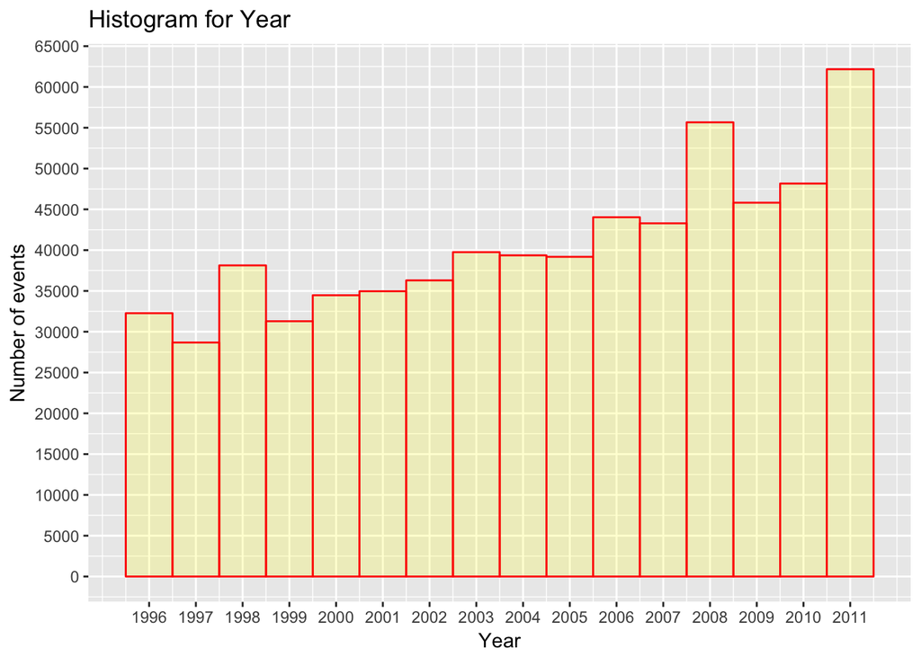

```r
ggplot(data = StormData, aes(x = Year))+
        geom_histogram(binwidth = 1,
                       col = "red",
                       fill = "yellow",
                       alpha = .2)+
        labs(title = "Histogram for Year")+
        labs(x = "Year", y = "Number of events")+
        scale_x_continuous(breaks = seq(1996, 2011, 1))+
        scale_y_continuous(breaks=seq(0,65000,5000))
```

```r
Events <- unique(StormData$EVTYPE)
length(Events)
```

```
## [1] 516
```